# 05_29_19_cluster_Olivierdata slides

Here we use our pca package to analysis the battery testing data from Olivier as an exmple. The data set contains 11 features with 37 datapoints for each feature:

```python
data = pd.read_excel('../../fullParamLTO.xlsx')
data.head()
```

|  | AM | CB | CNF | Binder | BinderType | Electrode Weight (mg) | Thickness (um) | Active Material Weight (mg) | Theoritical Capacity (mAh) | Porosity (%v) | Capacity (mAh/g_electrode) |
| --- | --- | --- | --- | --- | --- | --- | --- | --- | --- | --- | --- |
| 0 | 0.770222 | 0.199721 | 0.000000 | 0.030057 | 1 | 10.816667 | 34.666667 | 8.330997 | 1.416269 | 48.988694 | 72.323717 |
| 1 | 0.864363 | 0.000000 | 0.100045 | 0.035592 | 2 | 10.266667 | 34.333333 | 8.874507 | 1.508666 | 48.780666 | 77.158070 |
| 2 | 0.950291 | 0.005541 | 0.000000 | 0.044168 | 2 | 9.386667 | 28.000000 | 8.920149 | 1.516425 | 46.293032 | 47.540774 |
| 3 | 0.785186 | 0.038444 | 0.100006 | 0.076363 | 2 | 10.900000 | 37.666667 | 8.558680 | 1.454976 | 44.949558 | 74.461161 |
| 4 | 0.842186 | 0.080548 | 0.046913 | 0.030353 | 1 | 10.100000 | 31.666667 | 8.506220 | 1.446057 | 48.835171 | 92.511294 |

With the pca_analysis in nVision, we can do the pca analysis to the original data. We can obtain the newdata projected to each calculated compontent (corresponding to each colomn in the obtained dataset). The components are sorted by the varience explained each component.

```python
newdata, model, comps = pca.pca_analysis(data)
newdata.head()
```

|  | 0 | 1 | 2 | 3 | 4 | 5 | 6 | 7 | 8 | 9 | 10 |
| --- | --- | --- | --- | --- | --- | --- | --- | --- | --- | --- | --- |
| 0 | -2.197759 | 0.609337 | -0.550714 | 2.450127 | -0.825455 | 0.810025 | -0.870637 | 0.102023 | -0.038233 | -0.024571 | -2.922245e-15 |
| 1 | 0.915385 | -0.783022 | 2.570128 | -0.519887 | 0.647227 | -0.829464 | 0.131374 | 0.012304 | 0.033630 | 0.110904 | 1.474921e-16 |
| 2 | 2.173233 | -1.991436 | 0.826539 | -0.133919 | 0.993362 | 1.452476 | -0.645838 | 0.147234 | -0.005751 | -0.012801 | 3.576606e-16 |
| 3 | -0.512684 | 0.777225 | 1.398643 | -0.395159 | 0.817335 | -1.124040 | 0.497979 | -0.096558 | 0.023936 | 0.038389 | 1.349827e-15 |
| 4 | -1.027219 | -0.965157 | 0.547004 | 0.578639 | -1.125027 | -0.209952 | -0.315385 | 0.072329 | -0.021045 | 0.041778 | 5.336599e-15 |

The outout variable comps gives the obtained components from the pca analysis. It describes how the original space (each row is associated with one original feature in the same order as in the original dataset) is projected to the new feature space.

```python
comps
```

|  | 0 | 1 | 2 | 3 | 4 | 5 | 6 | 7 | 8 | 9 | 10 |
| --- | --- | --- | --- | --- | --- | --- | --- | --- | --- | --- | --- |
| 0 | 0.210040 | -0.290346 | -0.119899 | 0.125441 | 2.380823e-01 | -5.688890e-02 | -4.677872e-01 | 4.073004e-01 | 3.702607e-01 | 4.491838e-01 | -2.407779e-01 |
| 1 | -0.533591 | 0.199682 | 0.181959 | 0.395727 | -1.229058e-02 | 5.422993e-01 | -4.292633e-03 | 1.159154e-02 | -7.086592e-03 | 1.657646e-01 | -4.046951e-01 |
| 2 | -0.026060 | -0.005725 | 0.476840 | -0.321845 | -4.836331e-03 | 2.120526e-01 | 2.865297e-01 | 4.653781e-01 | 5.097648e-01 | -2.209810e-01 | 1.263692e-01 |
| 3 | -0.106115 | 0.699922 | -0.312407 | -0.415194 | 2.175554e-01 | 1.462486e-01 | -1.895663e-01 | 9.256780e-02 | 4.421680e-02 | 2.444753e-01 | 2.322017e-01 |
| 4 | 0.042329 | -0.009675 | 0.002791 | -0.051720 | 8.708544e-01 | -5.484380e-02 | 2.399892e-01 | -7.508864e-02 | -9.838544e-02 | -2.490248e-01 | -3.148181e-01 |
| 5 | 0.091567 | 0.139572 | -0.679626 | 0.229087 | -2.043211e-01 | 1.816213e-02 | 3.291003e-01 | 2.454420e-01 | 2.843821e-01 | -3.300085e-01 | -2.394967e-01 |
| 6 | -0.116401 | -0.172540 | -0.144145 | 0.476570 | 2.957623e-01 | 2.080669e-01 | 5.839045e-02 | 1.850610e-01 | -5.237954e-02 | -3.019532e-02 | 7.326016e-01 |
| 7 | 0.135770 | -0.047311 | -0.005743 | -0.135839 | -8.961824e-02 | 1.523446e-01 | -6.403074e-03 | 6.375927e-01 | -7.104577e-01 | -5.602639e-02 | -1.230783e-01 |
| 8 | 0.320553 | -0.189513 | -0.117314 | -0.151384 | -1.256386e-02 | 3.698461e-01 | 5.678445e-01 | -1.821317e-01 | -2.999049e-02 | 5.754750e-01 | 4.049787e-03 |
| 9 | -0.317307 | 0.176688 | 0.113151 | 0.164710 | 3.583631e-03 | -6.555117e-01 | 4.139111e-01 | 2.626831e-01 | -4.577656e-02 | 3.949862e-01 | 4.700883e-03 |
| 10 | -0.643139 | -0.516900 | -0.343898 | -0.448242 | 7.284253e-16 | -3.590725e-15 | -5.344733e-15 | 2.860598e-15 | -1.083276e-15 | -5.311491e-15 | 9.455166e-16 |

Here the feature 10 (Capacity) contributes most to the component 0 and feature 3 (Binder) contributes most to the component 1

```python
data.columns[10]
```

```
'Capacity (mAh/g_electrode)'
```

```python
data.columns[3]
```

```
'Binder'
```

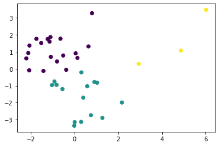

```python
from sklearn.cluster import MiniBatchKMeans, KMeans
from sklearn.metrics.pairwise import pairwise_distances_argmin
from sklearn.datasets.samples_generator import make_blobs
k_means = KMeans(init='k-means++', n_clusters=3, n_init=10)
k_means.fit(newdata)
plt.scatter(newdata[0], newdata[1], c=k_means.labels_)
```

The datapoints distributed in three groups as in the plot. The purple and blue clustors are mainly differentiated from the yellow by the component 0, assossiated mostly with the capacity in real feature space. The purple and blue clusters are more differentiated by the component 1, where is mostly correlated to the binder.